### Basic plot

We’re ready to plot the data using **ggplot()**, along with **geom_polygon()** and **coord_map()**. Note that in the aes statement, **group=group** does NOT change; “group” is a variable in the fortified dataframe so just leave it.

You do need to change “prevalence” to whatever variable you want to plot.

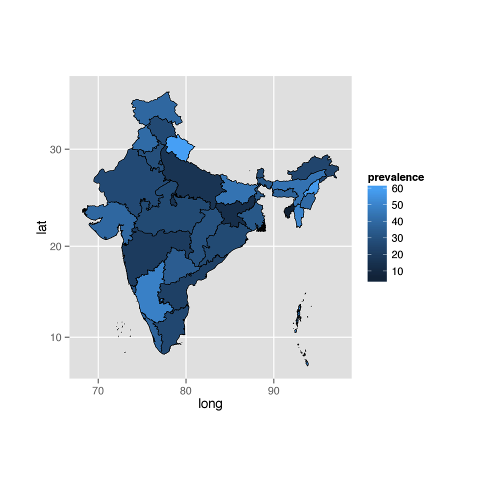

```r
#basic plot
ggplot() +
  geom_polygon(data = final.plot,
               aes(x = long, y = lat, group = group, fill = prevalence),
               color = "black", size = 0.25) +
  coord_map()
```

**Troubleshooting**: I have had many comments about an error occuring at this step, with usually this error:

Error in seq.default(from = best$lmin, to = best$lmax, by = best$lstep) : ‘from’ must be of length 1

If you receive this error, that means that the shapefile **did not merge properly** with the mapping data. Go back to the **Important Note** above, and follow the instructions for making sure you have unique and matching IDs across your shapefile and mapping data.

### Making the map pretty

This is a great start, but there are a number of options that can make the map look much nicer. First, we can remove the background and gridlines by including **theme_nothing()** from the ggmap package, but indicating that we still want the legend. We can also change the title of the legend and add in a title for the whole map.

Next, we can change the palette to “YlGn” which is Yellow to Green. You can find palette options as well as help on color in R [here](https://www.nceas.ucsb.edu/~frazier/RSpatialGuides/colorPaletteCheatsheet.pdf), or type in **display.brewer.all()** to see a plot of them in R.

We can also use **pretty_breaks()** from the scales package to get nice break points (the pretty algorithm creates a sequence of about n+1 equally spaced round values, that are 1, 2, or 5 times a power of 10). If you don’t like the way **pretty_breaks** looks, you can change your scale with **scale_fill_gradient()** and set the limits and colors like this:

**scale_fill_gradient(name=“My var”, limits=c(0,100), low=“white”, high=“red”)** I do this in the third map, below.

More about using color gradients in R, [here](http://docs.ggplot2.org/current/scale_gradient.html).

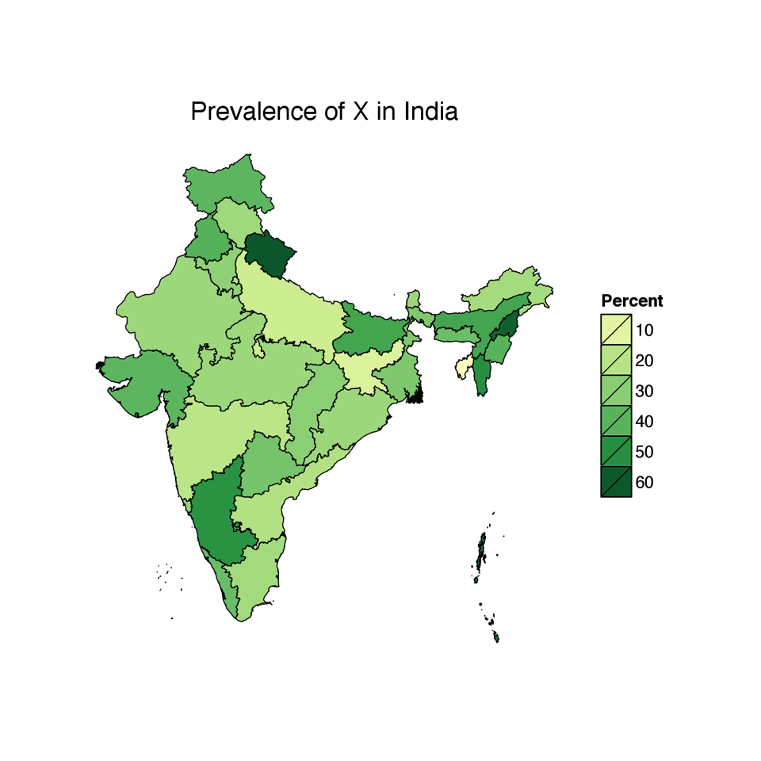

```r
#nicer plot
ggplot() +
  geom_polygon(data = final.plot,
               aes(x = long, y = lat, group = group, fill = prevalence),
               color = "black", size = 0.25) +
  coord_map()+
  scale_fill_distiller(name="Percent", palette = "YlGn", breaks = pretty_breaks(n = 5))+
  theme_nothing(legend = TRUE)+
  labs(title="Prevalence of X in India")
```

Other options:

If we were plotting a discrete variable instead of a continuous one, we would use **scale_fill_manual** instead of distiller, like this:

**scale_fill_manual(name=“My discrete variable”, values=c(“red”, “blue”, “green”, “yellow”))**

Additionally, we can put the names of the states on the map. This may or may not be a great idea depending on the size of the areas you’re mapping, but if it’s useful, you can do it easily using **geom_text()**. First we need to identify a longitude and latitude where you want to plot each state name. One way we can do this is using **aggregate()** to calculate the mean of the range of the longitude and latitude for each state.

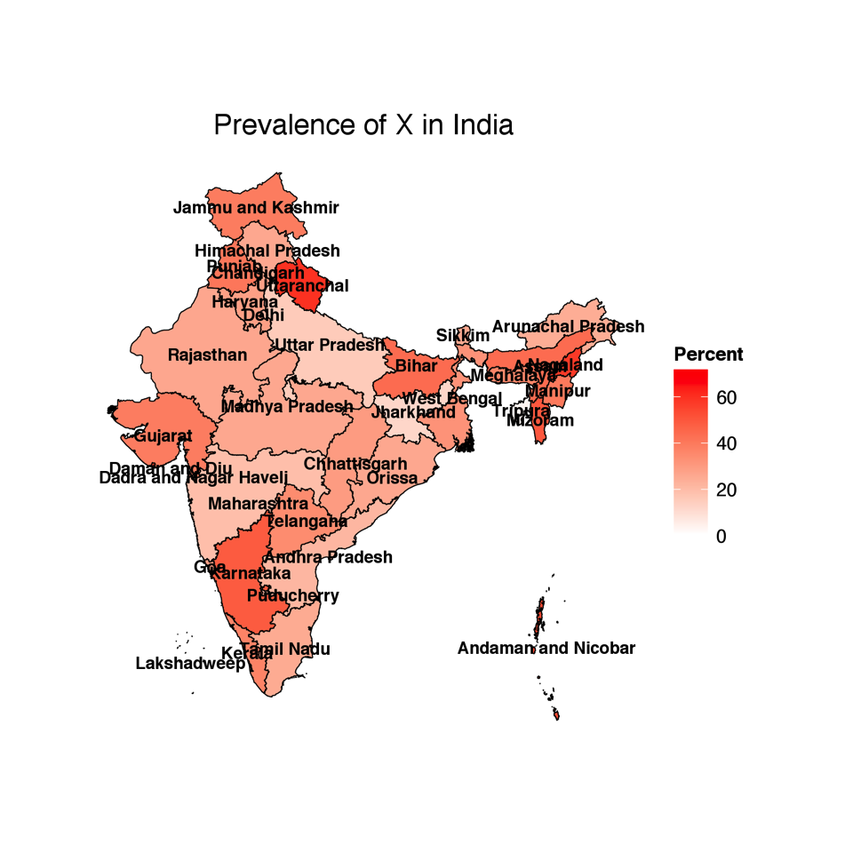

```r
#aggregate data to get mean latitude and mean longitude for each state
cnames <- aggregate(cbind(long, lat) ~ NAME_1, data=final.plot, FUN=function(x) mean(range(x)))

#plot using geom_text
ggplot() +
  geom_polygon(data = final.plot,
               aes(x = long, y = lat, group = group, fill = prevalence),
               color = "black", size = 0.25) +
  coord_map() +
  scale_fill_gradient(name="Percent", limits=c(0,70), low="white", high="red")+
  theme_nothing(legend = TRUE)+
  labs(title="Prevalence of X in India")+
  geom_text(data=cnames, aes(long, lat, label = NAME_1), size=3, fontface="bold")
```

This doesn’t look great on this particular map, but it may be useful in other settings. You could also use **geom_text()** to put other text on the map to identify certain features or highlight an area.

### Exporting map

Finally, one way we can export the map is by using Cairo. For this to work on my mac, I had to install X11, found [here](http://xquartz.macosforge.org/landing/).

We save the plot in an object and then use **ggsave()** to export the object as a png. First save the ggplot statement in an object, and then export with ggsave, indicating the width and height. You can also specify the dpi (default is 300).

Another way to save to pdf is via the pdf function, also shown below.

```r
#save map
p2 <- ggplot() +
  geom_polygon(data = final.plot,
               aes(x = long, y = lat, group = group, fill = prevalence),
               color = "black", size = 0.25) +
  coord_map()+
  scale_fill_distiller(name="Percent", palette = "Reds", breaks = pretty_breaks(n = 4))+
  theme_nothing(legend = TRUE)+
  labs(title="Prevalence of X in India")

ggsave(p2, file = "map1.png", width = 6, height = 4.5, type = "cairo-png")

#another way to save
pdf("mymap.pdf")
print(p2)
dev.off()
```